# Predictive Analysis Competition Project

## MODELING AND FEATURE SELECTION STARTS HERE

## FEATURE SELECTION 1: BEST SUBSET STARTS HERE

```r
subsets = regsubsets(rating~track_duration+track_explicit+danceability+energy+key+loudness+mode+speechiness+acousticness+instrumentalness+liveness+valence+tempo+time_signature,data= songs, nvmax=14)
summary(subsets)
```

```
## Subset selection object
## Call: regsubsets.formula(rating ~ track_duration + track_explicit +
##     danceability + energy + key + loudness + mode + speechiness +
##     acousticness + instrumentalness + liveness + valence + tempo +
##     time_signature, data = songs, nvmax = 14)
## 14 Variables  (and intercept)
##                    Forced in Forced out
## track_duration         FALSE      FALSE
## track_explicitTRUE     FALSE      FALSE
## danceability           FALSE      FALSE
## energy                 FALSE      FALSE
## key                    FALSE      FALSE
## loudness               FALSE      FALSE
## mode                   FALSE      FALSE
## speechiness            FALSE      FALSE
## acousticness           FALSE      FALSE
## instrumentalness       FALSE      FALSE
## liveness               FALSE      FALSE
## valence                FALSE      FALSE
## tempo                  FALSE      FALSE
## time_signature         FALSE      FALSE
## 1 subsets of each size up to 14
## Selection Algorithm: exhaustive
##           track_duration track_explicitTRUE danceability energy key loudness
## 1  ( 1 )  " "            " "                " "          " "    " " " "
## 2  ( 1 )  "*"            " "                " "          " "    " " "*"
## 3  ( 1 )  " "            " "                "*"          " "    " " "*"
## 4  ( 1 )  "*"            " "                "*"          " "    " " "*"
## 5  ( 1 )  "*"            " "                "*"          " "    " " "*"
## 6  ( 1 )  "*"            " "                "*"          " "    " " "*"
## 7  ( 1 )  "*"            " "                "*"          "*"    " " "*"
## 8  ( 1 )  "*"            " "                "*"          "*"    " " "*"
## 9  ( 1 )  "*"            " "                "*"          "*"    " " "*"
## 10  ( 1 ) "*"            " "                "*"          "*"    " " "*"
## 11  ( 1 ) "*"            "*"                "*"          "*"    " " "*"
## 12  ( 1 ) "*"            "*"                "*"          "*"    " " "*"
## 13  ( 1 ) "*"            "*"                "*"          "*"    " " "*"
## 14  ( 1 ) "*"            "*"                "*"          "*"    "*" "*"
##           mode speechiness acousticness instrumentalness liveness valence tempo
## 1  ( 1 )  " "  " "         "*"          " "              " "      " "     " "
```

[output cut: 13 more lines]

```
##           time_signature
## 1  ( 1 )  " "
## 2  ( 1 )  " "
## 3  ( 1 )  " "
## 4  ( 1 )  " "
## 5  ( 1 )  " "
## 6  ( 1 )  " "
## 7  ( 1 )  " "
## 8  ( 1 )  "*"
## 9  ( 1 )  "*"
## 10  ( 1 ) "*"
## 11  ( 1 ) "*"
## 12  ( 1 ) "*"
## 13  ( 1 ) "*"
## 14  ( 1 ) "*"
```

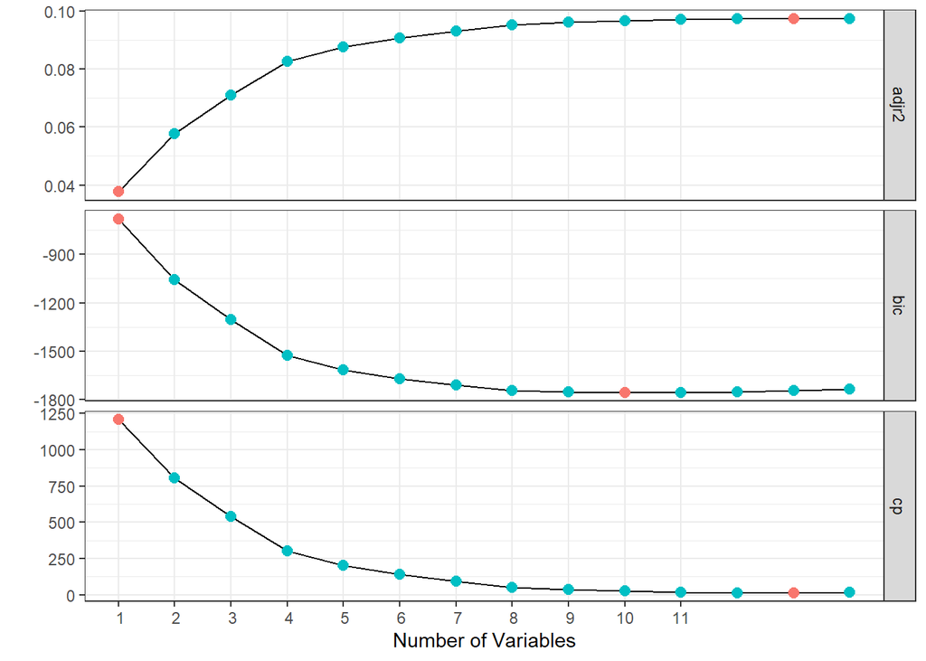

```r
subsets_measures = data.frame(model=1:length(summary(subsets)$cp),
                             cp=summary(subsets)$cp,
                             bic=summary(subsets)$bic,
                             adjr2=summary(subsets)$adjr2)
subsets_measures %>%
          gather(key = type, value=value, 2:4)%>%
          group_by(type)%>%
          mutate(best_value = factor(ifelse(value == min(value) | value== max(value),0,1)))%>%
          ungroup()%>%
          ggplot(aes(x=model,y=value))+
          geom_line(color='gray2')+
          geom_point(aes(color = best_value), size=2.5)+
          scale_x_discrete(limits = seq(1,11,1),name = 'Number of Variables')+
          scale_y_continuous(name = '')+
          guides(color=F)+
          theme_bw()+
          facet_grid(type~.,scales='free_y')
```

… ## FEATURE SELECTION 1: BEST SUBSET ENDS HERE

## FEATURE SELECTION 2: BEST SUBSET STARTS HERE

```r
subsets = regsubsets(rating~track_duration+track_explicit+danceability+energy+key+loudness+mode+speechiness+acousticness+instrumentalness+liveness+valence+tempo+time_signature+pop+hiphop_rap+rock+dance_electronic+latin+indie_alternative+classical+k_pop+country+metal,data= songs, nvmax=24)
summary(subsets)
```

```
## Subset selection object
## Call: regsubsets.formula(rating ~ track_duration + track_explicit +
##     danceability + energy + key + loudness + mode + speechiness +
##     acousticness + instrumentalness + liveness + valence + tempo +
##     time_signature + pop + hiphop_rap + rock + dance_electronic +
##     latin + indie_alternative + classical + k_pop + country +
##     metal, data = songs, nvmax = 24)
## 24 Variables  (and intercept)
##                    Forced in Forced out
## track_duration         FALSE      FALSE
## track_explicitTRUE     FALSE      FALSE
## danceability           FALSE      FALSE
## energy                 FALSE      FALSE
## key                    FALSE      FALSE
## loudness               FALSE      FALSE
```

[output cut: 120 more lines]

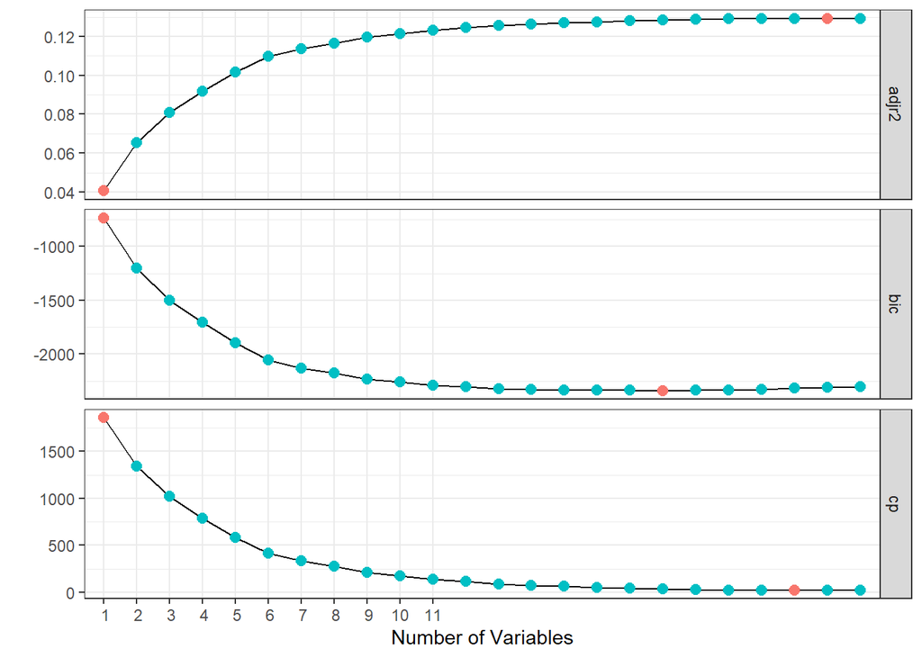

```r
subsets_measures = data.frame(model=1:length(summary(subsets)$cp),
                             cp=summary(subsets)$cp,
                             bic=summary(subsets)$bic,
                             adjr2=summary(subsets)$adjr2)
subsets_measures %>%
          gather(key = type, value=value, 2:4)%>%
          group_by(type)%>%
          mutate(best_value = factor(ifelse(value == min(value) | value== max(value),0,1)))%>%
          ungroup()%>%
          ggplot(aes(x=model,y=value))+
          geom_line(color='gray2')+
          geom_point(aes(color = best_value), size=2.5)+
          scale_x_discrete(limits = seq(1,11,1),name = 'Number of Variables')+
          scale_y_continuous(name = '')+
          guides(color=F)+
          theme_bw()+
          facet_grid(type~.,scales='free_y')
```

## FEATURE SELECTION 2: BEST SUBSET ENDS HERE

## MODEL 2: LINEAR REGRESSION WITH RANDOM FEATURES

```r
model2 = lm(rating~track_duration+track_explicit+danceability+energy+loudness+acousticness,train)
```

## MODEL 2: LINEAR REGRESSION WITH RANDOM FEATURES

## MODEL 3: LINEAR REGRESSION WITH ALL FEATURES

```r
model3 = lm(rating~track_duration+track_explicit+danceability+energy+key+loudness+mode+speechiness+acousticness+instrumentalness+liveness+valence+tempo+time_signature,train)
```

## MODEL 3: LINEAR REGRESSION WITH ALL FEATURES

## MODEL 4: LINEAR REGRESSION WITH FEATURES FROM FEATURE SELECTION 1 STARTS HERE

```r
model4 = lm(rating~track_duration+track_explicit+danceability+energy+loudness+mode+speechiness+acousticness+instrumentalness+liveness+valence+tempo+time_signature,train)
```

## MODEL 4: LINEAR REGRESSION WITH FEATURES FROM FEATURE SELECTION 1 ENDS HERE

## MODEL 5: GAM WITH FEATURES FROM FEATURE SELECTION 1 STARTS HERE

```r
model5 = gam(rating ~ s(track_duration)+track_explicit+s(danceability)+s(energy)+s(loudness)+mode+s(speechiness)+s(acousticness)+s(instrumentalness)+s(liveness)+s(valence)+s(tempo)+time_signature,
                   method = 'REML',
                   data = train)
```

## MODEL 5: GAM WITH FEATURES FROM FEATURE SELECTION 1 ENDS HERE

## MODEL 6: BAGGED RANDOM FOREST WITH FEATURES FROM FEATURE SELECTION 1 STARTS HERE

```r
set.seed(617)
model6 = randomForest(rating~track_duration+track_explicit+danceability+energy+loudness+mode+speechiness+acousticness+instrumentalness+liveness+valence+tempo+time_signature,data=train,mtry = ncol(train),ntree=1000)
```

## MODEL 6: BAGGED RANDOM FOREST WITH FEATURES FROM FEATURE SELECTION 1 ENDS HERE

## MODEL 7: BOOST WITH FEATURES FROM FEATURE SELECTION 1 STARTS HERE

```r
set.seed(1031)
model7 = gbm(rating~track_duration+track_explicit+danceability+energy+loudness+mode+speechiness+acousticness+instrumentalness+liveness+valence+tempo+time_signature,
            data=train,
            distribution="gaussian",
            n.trees = 100,
            interaction.depth = 3,
            shrinkage = 0.081,
            n.minobsinnode=c(2))
```

## MODEL 7: BOOST WITH FEATURES FROM FEATURE SELECTION 1 ENDS HERE

## MODEL 8: LINEAR REGRESSION WITH FEATURES FROM FEATURE SELECTION 2 STARTS HERE

```r
model8 = lm(rating~track_duration+track_explicit+danceability+energy+loudness+speechiness+acousticness+instrumentalness+liveness+valence+tempo+time_signature+pop+hiphop_rap+rock+dance_electronic+latin+indie_alternative+classical+k_pop+country+metal,train)
```

## MODEL 8: LINEAR REGRESSION WITH FEATURES FROM FEATURE SELECTION 2 ENDS HERE

## MODEL 9: BOOST WITH FEATURES FROM FEATURE SELECTION 2 STARTS HERE

```r
set.seed(1031)
model9 = gbm(rating~track_duration+track_explicit+danceability+energy+loudness+speechiness+acousticness+instrumentalness+liveness+valence+tempo+time_signature+pop+hiphop_rap+rock+dance_electronic+latin+indie_alternative+classical+k_pop+country+metal,
data=train,
distribution="gaussian",
n.trees = 100,
interaction.depth = 3,
shrinkage = 0.081,#
n.minobsinnode=c(2))
```

## MODEL 9: BOOST WITH FEATURES FROM FEATURE SELECTION 2 ENDS HERE

## MODEL 10: BAGGED RANDOM FOREST WITH FEATURES FROM FEATURE SELECTION 2 STARTS HERE

```r
set.seed(617)
model10 = randomForest(rating~track_duration+track_explicit+danceability+energy+loudness+speechiness+acousticness+instrumentalness+liveness+valence+tempo+time_signature+pop+hiphop_rap+rock+dance_electronic+latin+indie_alternative+classical+k_pop+country+metal,data=train,mtry = 22, ntree=200)
```

## MODEL 10: BAGGED RANDOM FOREST WITH FEATURES FROM FEATURE SELECTION 2 ENDS HERE

## RMSE PREDECTION STARTS HERE

```
## Using 100 trees...
##
## Using 100 trees...
##
## Using 100 trees...
##
## Using 100 trees...
```

## RMSE PREDECTION ENDS HERE

## MODELING AND FEATURE SELECTION ENDS HERE

Model Comparison

The model that performed the best was model10 which was a bagged random forest model that utilized the 2nd feature selection.

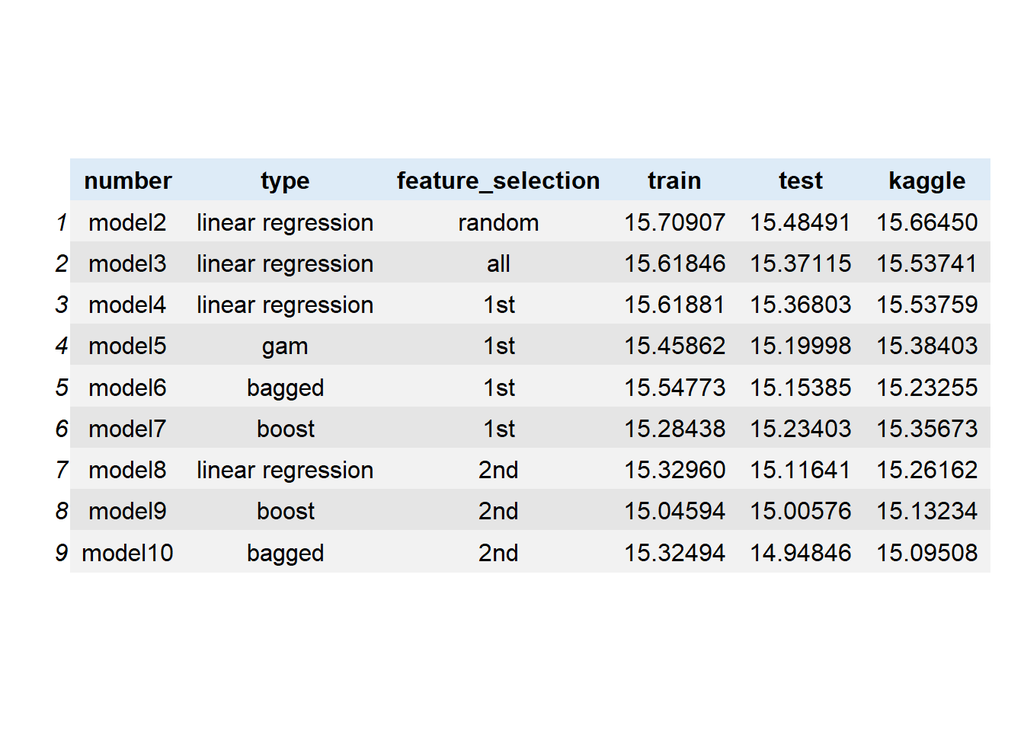

Discussion

Future directions

If I had more time with this project, I would attempt to run more models with the 2nd feature selection. In particular, I would attempt a tuned boost model as the boost model was my 2nd best model. Tuning could help increase performance by manipulating the parameters. Additionally, I could have ran a bagged random forest model with an increased number of trees. Increasing the number of trees from 200 to 1000 could have proved to be a better model as variance could have been decreased more. Attempting a random forest, tuned random forest, ranger, and tuned ranger would also be considered as I did not test these models. Other than attempting more models, I may have manipulated the genre variable even more. It is possible if I increased the number of dummy variables and included niche genres, prediction could have been increased. Additionally, I would have liked to compare niche genre variables vs. the top 10 genre variables to confirm my previous hypothesis.